# Open Forensic Science book

Following [this book](https://sctyner.github.io/OpenForSciR/intro.html) with its [github repo](https://github.com/sctyner/OpenForSciR).

Set-up:

```r
options(repos = "http://cran.us.r-project.org")

# check if a package is installed, if not install it from cran
install_cran_missing <- function(pkgname){
  if(class(pkgname) != "character"){
    stop("pkgname must be a character")
  }
  if (!require(pkgname, character.only = TRUE, quietly = TRUE)){
    install.packages(pkgname, dep = T)
    if(!require(pkgname,character.only = TRUE)) stop("CRAN Package not found")
  }
}
# check if a package is installed, if not install it from Github
install_dev_missing <- function(pkgname, ghuser){
  if(class(pkgname) != "character"){
    stop("pkgname must be a character")
  }
  if (!require(pkgname, character.only = TRUE, quietly = TRUE)){
    repo <- paste(ghuser, pkgname, sep ='/')
    devtools::install_github(repo)
    if(!require(pkgname,character.only = TRUE)) stop("Github repo for package not found")
  }
}

# need devtools to get some packages
install_cran_missing("devtools")
# packages used throughout the book
install_cran_missing("tidyverse") # or install_dev_missing("tidyverse", "tidyverse")

#install_dev_missing("gt", "rstudio")
# this did not work, so had to do:
install.packages("gt")

# Chapter 2: DNA Validation
# Watch out for dependency issues with RGtk2...
# install_cran_missing("strvalidator")
# this did not work, so had to do:
install.packages("strvalidator")
```

Important quote: “Notice the distinction: the forensic scientist is not a member of law enforcement, so their main concern is not “catching the bad guy.” Instead, they are concerned with coming to the best conclusion using science."

## Chapter 2: Validation of DNA

- Short Tandem Repeats (STRs) - Multiple copies of an identical DNA sequence arranged in direct succession where the repeat sequence unit is 2 to 6 base pairs in length.
- At each locus, the number of times a tetranucleotide sequence (e.g. AAGC) repeats is counted (Butler 2005). This count indicates the allele, or gene variation, at that particular locus.
- As of January 1, 2017, there are 20 core loci in CODIS, the Combined DNA Index System, which is the FBI’s national program for DNA databases and software.
- These sets of loci were chosen because of their high variability in the population.
- To find the alleles at each loci, the DNA sample is amplified using PCR, and then run through capillary electrophoresis (CE). The result of CE is the DNA profile, with the alleles on each locus indicated by different colored peaks from a chemical dyeing process.
- The strvalidator package makes the validation process faster by automating data analysis with respect to “heterozygote balance, stutter ratio, inter-locus balance, and the stochastic threshold” [Hansson et al 2014](https://www.sciencedirect.com/science/article/pii/S1872497314001574?via%3Dihub).

```r
library(strvalidator)
library(dplyr)
```

```r
library(ggplot2)
data(set1)
head(set1)
```

```
##   Sample.Name   Marker Dye Allele.1 Allele.2 Allele.3 Allele.4 Allele.5
## 1         PC1     AMEL   B        X       OL        Y     <NA>     <NA>
## 2         PC1  D3S1358   B       16       17       18     <NA>     <NA>
## 3         PC1     TH01   B        6      9.3     <NA>     <NA>     <NA>
## 4         PC1   D21S11   B       28       29     30.2     31.2     <NA>
## 5         PC1   D18S51   B       15       16       17       18     <NA>
## 6         PC1 D10S1248   G       12       13       14       15     <NA>
##   Height.1 Height.2 Height.3 Height.4 Height.5
## 1     2486       81     2850     <NA>     <NA>
## 2      260     3251     2985     <NA>     <NA>
## 3     3357     2687     <NA>     <NA>     <NA>
## 4      183     2036      180     1942     <NA>
## 5      161     2051      203     1617     <NA>
## 6      168     2142      243     2230     <NA>
```

Data is usually stored in a wide format (columns as alleles and heights) and we need a long format: one column “Allele” and one column “height”

```r
# slim and trim the data
set1.slim <- slim(set1, fix = c("Sample.Name", "Marker", "Dye"), stack = c("Allele",
    "Height"), keep.na = FALSE)
dim(set1)
```

```
## [1] 170  13
```

```r
dim(set1.slim)
```

```
## [1] 575   5
```

```r
head(set1.slim)
```

```
##   Sample.Name  Marker Dye Allele Height
## 1         PC1    AMEL   B      X   2486
## 2         PC1    AMEL   B     OL     81
## 3         PC1    AMEL   B      Y   2850
## 4         PC1 D3S1358   B     16    260
## 5         PC1 D3S1358   B     17   3251
## 6         PC1 D3S1358   B     18   2985
```

We use `generateEPG()` to visualize an electropherogram-like plot of the data:

```r
p <- set1.slim %>% filter(Sample.Name != "Ladder") %>% generateEPG(kit = "ESX17")
```

```
## Collapse dataset to mean peak heights over multiple samples.
```

```
## Collapse dataset by adding peak heights for all profiles.
```

```
## 'Size' information not in 'data'.
```

```
## Added estimated 'Size' information.
```

```
## 5 rows with Size=NA removed.
```

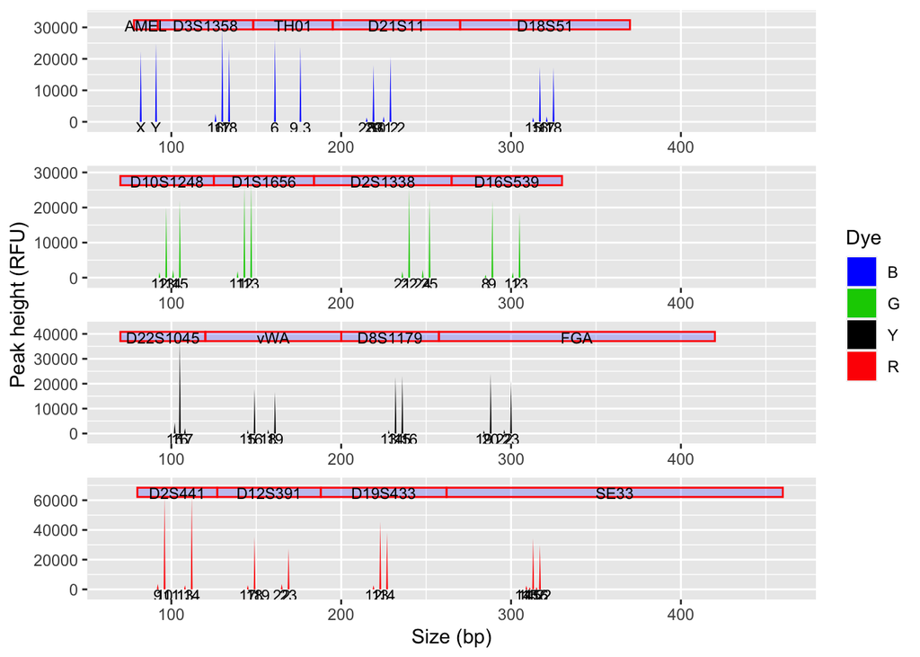

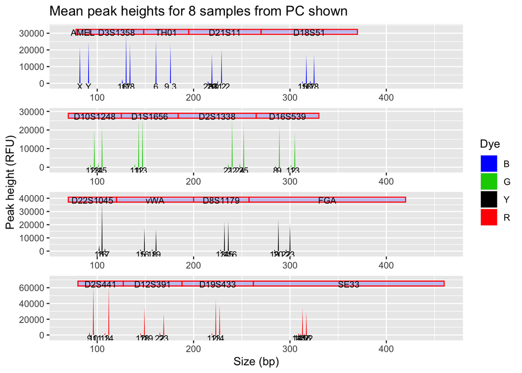

```r
p + ggtitle("Mean peak heights for 8 samples from PC shown")
```

Next, get the reference sample data.

```r
data(ref1)
head(ref1)
```

```
##   Sample.Name   Marker Allele.1 Allele.2
## 1          PC     AMEL        X        Y
## 2          PC  D3S1358       17       18
## 3          PC     TH01        6      9.3
## 4          PC   D21S11       29     31.2
## 5          PC   D18S51       16       18
## 6          PC D10S1248       13       15
```

```r
ref1.slim <- slim(ref1, fix = c("Sample.Name", "Marker"), stack = "Allele",
    keep.na = FALSE)
head(ref1.slim)
```

```
##   Sample.Name  Marker Allele
## 1          PC    AMEL      X
## 2          PC    AMEL      Y
## 3          PC D3S1358     17
## 4          PC D3S1358     18
## 5          PC    TH01      6
## 6          PC    TH01    9.3
```

and plot:

```r
p <- generateEPG(ref1.slim, kit = "ESX17") + ggtitle("True profile for sample PC")
```

```
## 'Height' is missing. Using default!
```

```
## 'Dye' information not in 'data'.
```

```
## A column 'Color' already exist in data frame!
```

```
## Added 'Dye' information.
```

```
## Collapse dataset to mean peak heights over multiple samples.
```

```
## Collapse dataset by adding peak heights for all profiles.
```

```
## 'Size' information not in 'data'.
```

```
## Added estimated 'Size' information.
```

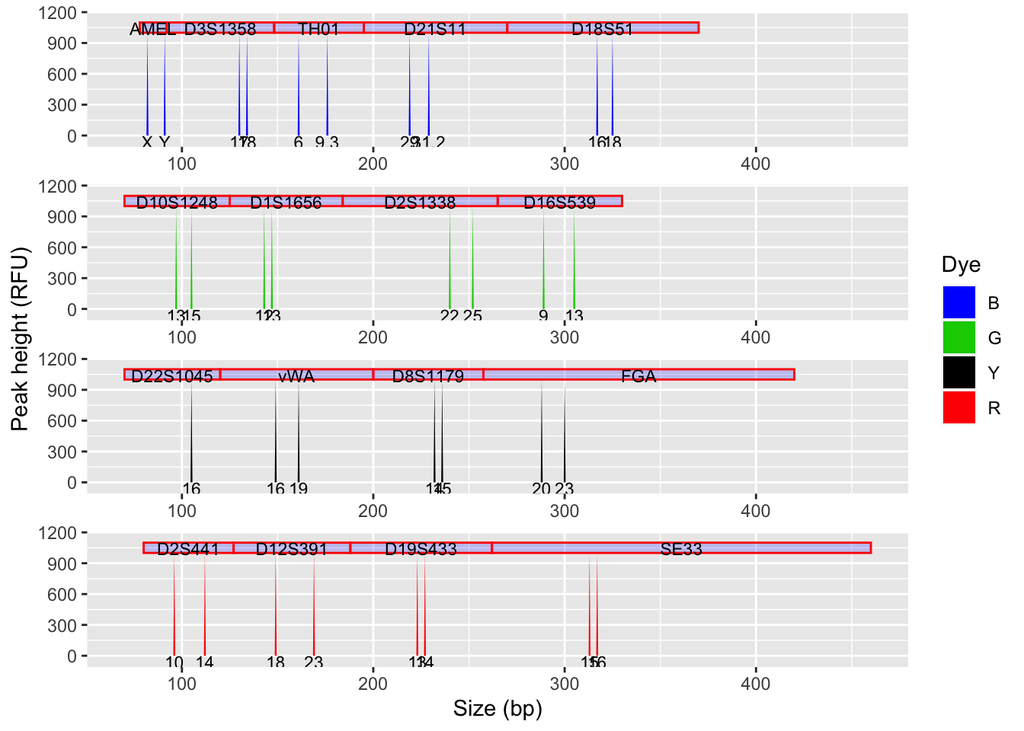

### Check stutter ratio

We calculate the stutter for the eight replicates in set1 using one back stutter, no forward stutter and no overlap.

```r
# make sure the right samples are being analyzed
checkSubset(data = set1.slim, ref = ref1.slim)
```

```
## Reference name: PC
## Subsetted samples: PC1, PC2, PC3, PC4, PC5, PC6, PC7, PC8
```

```r
# supply the false stutter and true stutter values for your data. these are
# from the GUI.
stutter_false_val <- c(-1.9, -1.8, -1.7, -0.9, -0.8, -0.7, 0.9, 0.8, 0.7)
stutter_replace_val <- c(-1.3, -1.2, -1.1, -0.3, -0.2, -0.1, 0.3, 0.2, 0.1)
# calculate the stutter values
set1_stutter <- calculateStutter(set1.slim, ref1.slim, back = 1, forward = 0,
    interference = 0, replace.val = stutter_false_val, by.val = stutter_replace_val)
```

```
## 'Height' must be numeric. 'data' converted!
```

```r
stutterplot <- addColor(set1_stutter, kit = "ESX17") %>% sortMarker(kit = "ESX17",
    add.missing.levels = FALSE)
```

```
## A column 'Color' already exist in data frame!
```

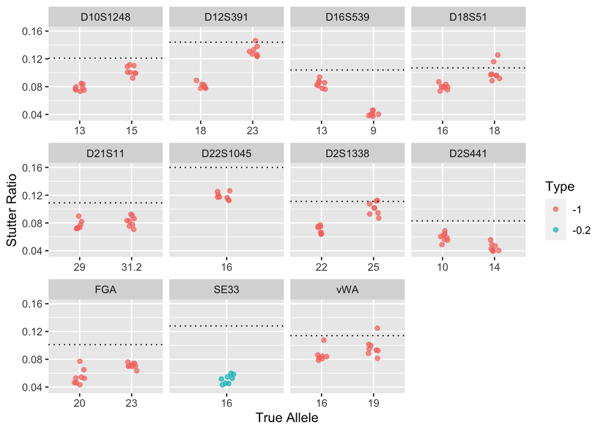

```r
marks <- levels(stutterplot$Marker)[-1]
stutterplot$Marker <- factor(as.character(stutterplot$Marker), levels = marks)
compare_dat <- data.frame(Marker = ref1$Marker[-1], perc95 = (c(11.9, 4.6, 10.9,
    10.7, 12.1, 12, 11.1, 10.4, 16, 11.4, 9.1, 10.1, 8.3, 14.4, 10.1, 12.8))/100)
compare_dat <- filter(compare_dat, Marker %in% stutterplot$Marker)

ggplot() + geom_point(data = stutterplot, position = position_jitter(width = 0.1),
    aes(x = Allele, y = Ratio, color = as.factor(Type)), alpha = 0.7) + geom_hline(data = compare_dat,
    aes(yintercept = perc95), linetype = "dotted") + facet_wrap(~Marker, ncol = 4,
    scales = "free_x", drop = FALSE) + labs(x = "True Allele", y = "Stutter Ratio",
    color = "Type")
```

- Stutter ratios by allele for each of the eight samples in the set1 data, computed for one back stutter, zero forward stutter, and no overlap. Note that SR increases with allele length (e.g. D10S1248; D2S1338; D12S391). Horizontal dotted lines represent the 95th percentile of stutter ratio values from the study done in Hansson, Gill, and Egeland (2014).

### Check for heterozygote balance (intra-locus balance)

Computing the heterozygote peak balance (Hb) is most important for analyzing samples with two or more contributors.

```r
set1_hb <- calculateHb(data = set1.slim, ref = ref1.slim, hb = 3, kit = "ESX17",
    sex.rm = TRUE, qs.rm = TRUE, ignore.case = TRUE)
```

```
## 'Height' not numeric. Converting to numeric.
```

```
## Extracting known alleles from dataset...
```

```
## Removing sex markers defined in kit: ESX17.
```

```
## Removing sex markers from dataset:
```

```
## Removed 25 rows with Marker=AMEL.
```

```
## Removing sex markers from reference dataset:
```

```
## Removed 2 rows with Marker=AMEL.
```

```
## Removing quality sensors defined in kit: ESX17.
```

```
## Removing quality sensors from dataset:
```

```
## Removing quality sensors from reference dataset:
```

```
## Using 'fast' allele filtering method.
```

```
## This method discards NA alleles/loci/samples.
```

```
## Removing gender markers and/or quality sensors from reference dataset...
```

```
## Removing sex markers defined in kit: ESX17.
```

```
## Removing sex markers from dataset:
```

```
## Removed 2 rows with Marker=AMEL.
```

```
## Removing quality sensors defined in kit: ESX17.
```

```
## Removing quality sensors from dataset:
```

```
## No allele filtering was performed.
```

```
## Replacing gender markers: X->1, Y->2
```

```
## Calculating allele distance: Delta=max(Allele) - min(Allele)...
```

```
## Extracting heterozygotes...
```

```
## Calculating mean peak height: MPH=(Small+Large)/2...
```

```
## Calculating heterozygote balance: Hb=Small/Large...
```

```r
hbplot <- addColor(set1_hb, kit = "ESX17") %>% sortMarker(kit = "ESX17", add.missing.levels = FALSE)
```

```
## A column 'Color' already exist in data frame!
```

```
## A column 'Dye' already exist in data frame!
```

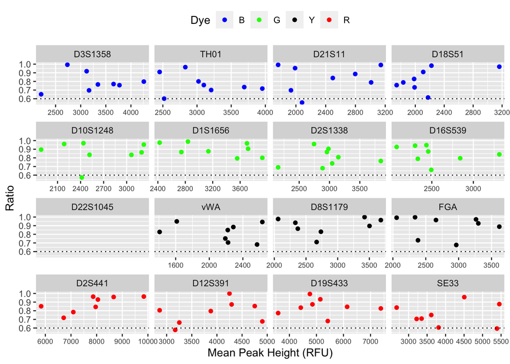

```r
hbplot$Marker <- factor(as.character(hbplot$Marker), levels = marks)


ggplot(data = hbplot) + geom_point(aes(x = MPH, y = Hb, color = Dye), position = position_jitter(width = 0.1)) +
    geom_hline(yintercept = 0.6, linetype = "dotted") + facet_wrap(~Marker,
    nrow = 4, scales = "free_x", drop = FALSE) + scale_color_manual(values = c("blue",
    "green", "black", "red")) + labs(x = "Mean Peak Height (RFU)", y = "Ratio",
    color = "Dye") + guides(color = guide_legend(nrow = 1)) + theme(axis.text.x = element_text(size = rel(0.8)),
    legend.position = "top")
```

The balance ratio is typically no less than 0.6 according to Gill, Sparkes, and Kimpton (1997), but there are a few exceptions to this rule in the set1 sample.

### Check inter-locus balance

Inter-locus balance (Lb) is a measure of peak balances across loci (Hansson, Gill, and Egeland 2014). The total height of the peaks in all loci should be spread evenly across each individual locus in a sample.

```r
set1_lb <- calculateLb(data = set1.slim, ref = ref1.slim, kit = "ESX17", option = "prop",
    by.dye = FALSE, ol.rm = TRUE, sex.rm = FALSE, qs.rm = TRUE, ignore.case = TRUE,
    na = 0)
```

```
## Preparing to calculate inter-locus balance.
```

```
## Removed 11 off-ladder alleles.
```

```
## Extracting known profiles and adding missing loci.
```

```
## Removing quality sensors defined in kit: ESX17.
```

```
## Removing quality sensors from dataset:
```

```
## Removing quality sensors from reference dataset:
```

```
## Using 'slow' allele filtering method.
```

```
## This method is required to keep NA alleles, add missing loci, or invert.
```

```
## 'Height' converted to numeric.
```

```
## Replaced 0 Height = NA with 0.
```

```
## Calculating total peak height by sample and marker.
```

```
## Calculating total profile peak height by sample.
```

```
## Calculating locus proportions of total profile peak height.
```

```r
set1_height <- calculateHeight(data = set1.slim, ref = ref1.slim, kit = "ESX17",
    sex.rm = FALSE, qs.rm = TRUE, na.replace = 0)
```

```
## The column 'Height' was converted to numeric.
```

```
## Extracting known alleles from dataset...
```

```
## Removing quality sensors defined in kit: ESX17.
```

```
## Removing quality sensors from dataset:
```

```
## Removing quality sensors from reference dataset:
```

```
## Using 'slow' allele filtering method.
```

```
## This method is required to keep NA alleles, add missing loci, or invert.
```

```
## Removing gender markers and/or quality sensors from reference dataset...
```

```
## Removing quality sensors defined in kit: ESX17.
```

```
## Removing quality sensors from dataset:
```

```
## No allele filtering was performed.
```

```
## Number of allele copies added to reference dataset.
```

```
## Converted data.table to data.frame (new.data).
```

```
## Expected number of alleles added to dataset.
```

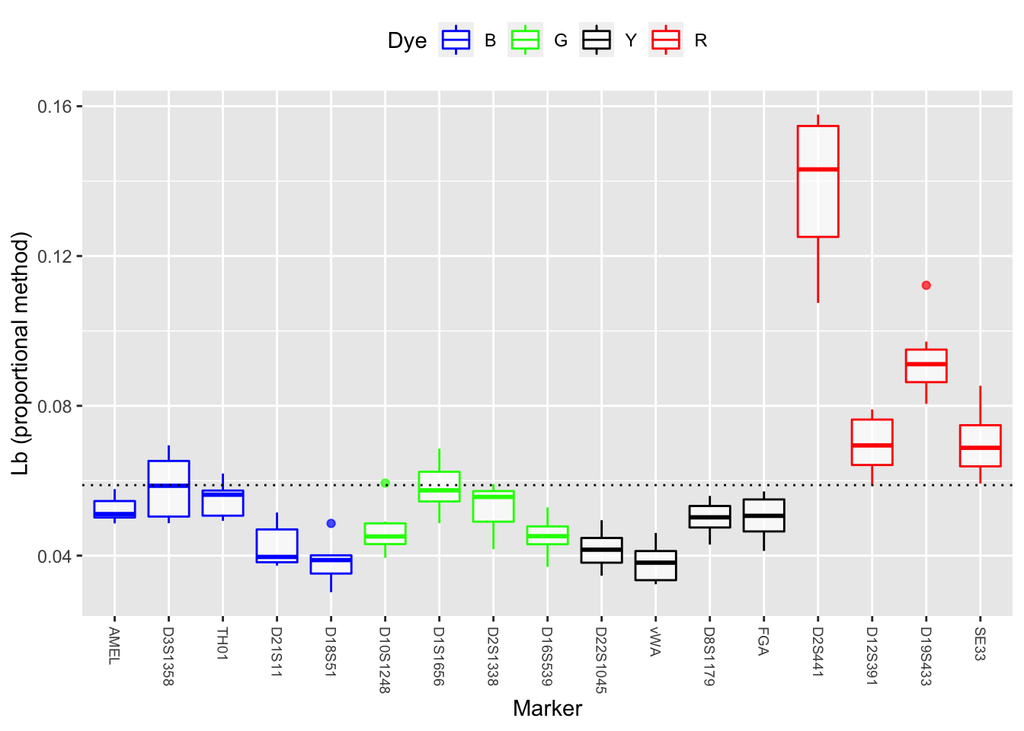

```r
set1_lb <- set1_lb %>% left_join(set1_height %>% select(Sample.Name:Marker,
    Dye, TPH, H, Expected, Proportion) %>% distinct(), by = c("Sample.Name",
    "Marker", "Dye", TPPH = "TPH"))


set1_lb <- sortMarker(set1_lb, kit = "ESX17", add.missing.levels = TRUE)

ggplot(set1_lb) + geom_boxplot(aes(x = Marker, y = Lb, color = Dye), alpha = 0.7) +
    scale_color_manual(values = c("blue", "green", "black", "red")) + geom_hline(yintercept = 1/17,
    linetype = "dotted") + theme(legend.position = "top", axis.text.x = element_text(size = rel(0.8),
    angle = 270, hjust = 0, vjust = 0.5)) + labs(y = "Lb (proportional method)")
```

In the set1 data, 17 loci are measured, thus each individual locus balance should be about 1/17th of the total height of all peaks in RFUs.

### Check stochastic threshold

The stochastic threshold is the value of interest for determining allele drop-out. As recommended in Butler (2009), we use an LDT of 50. The stochastic threshold is modeled with a logistic regression: - Source code [here](https://github.com/OskarHansson/strvalidator/blob/master/R/calculateDropout.r) - “Method X/1/2 records the peak height of the partner allele to be used as the explanatory variable in the logistic regression”

```r
set1_do <- calculateDropout(data = set1.slim, ref = ref1.slim, threshold = 50,
    method = "1", kit = "ESX17")
```

```
## 'Height' must be numeric. 'data' converted!
```

```
## Removing gender markers and/or quality sensors from dataset...
```

```
## Removing quality sensors defined in kit: ESX17.
```

```
## Removing quality sensors from dataset:
```

```
## No allele filtering was performed.
```

```
## Removing gender markers and/or quality sensors from reference dataset...
```

```
## Removing quality sensors defined in kit: ESX17.
```

```
## Removing quality sensors from dataset:
```

```
## No allele filtering was performed.
```

```r
table(set1_do$Dropout)
```

```
##
##   0
## 264
```

In set1, there is no dropout, as the samples included are control samples, and thus enough DNA is present during amplification so there are no stochastic effects.

The data set4 was created specifically for drop-out analysis, and contains 32 samples from three different reference profiles. The method = “1” argument computes dropout with respect to the low molecular weight allele in the locus.

```r
data(set4)
data(ref4)
set4_do <- calculateDropout(data = set4, ref = ref4, threshold = 50, method = "1",
    kit = "ESX17")
```

```
## 'Height' must be numeric. 'data' converted!
```

```
## Removing gender markers and/or quality sensors from dataset...
```

```
## Removing quality sensors defined in kit: ESX17.
```

```
## Removing quality sensors from dataset:
```

```
## No allele filtering was performed.
```

```
## Removing gender markers and/or quality sensors from reference dataset...
```

```
## Removing quality sensors defined in kit: ESX17.
```

```
## Removing quality sensors from dataset:
```

```
## No allele filtering was performed.
```

```r
table(set4_do$Dropout)
```

```
##
##   0   1   2
## 822  33  68
```

In the set4 data, 33 alleles dropped out (Dropout = 1), and locus dropout (Dropout = 2) occurred in 9 samples (68 alleles).

The probability of allele drop-out is computed via logistic regression of the dropout score with respect to the method 1, on the the height of the allele with low molecular weight.

The model parameters are also computed using the calculateT() function. This function also returns the smallest threshold value at which probability of dropout is less than or equal to a set value, typically 0.01 or 0.05, as well as a conservative threshold.

```r
set4_do2 <- set4_do %>% filter(Dropout != 2) %>% rename(Dep = Method1, Exp = Height)
do_mod <- glm(Dep ~ Exp, family = binomial("logit"), data = set4_do2)
set4_ths <- calculateT(set4_do2, pred.int = 0.98)
```

```
## Calculate point estimate for stochastic threshold.
```

```
## Observations (explanatory variable) n=855
```

```
## Observed values min=80 and max=31869
```

```
## Observations with dropout n=461
```

```
## Observations without dropout n=837
```

```r
set4_ths
```

```
##            T           Tc            p           B0           B1          obs
## 474.42122284 894.00000000   0.99761325   0.49250726  -0.01072386 837.00000000
##         drop
## 461.00000000
```

Next, we compute predicted dropout probabilities P(D) and corresponding 95% confidence intervals and plot the results.

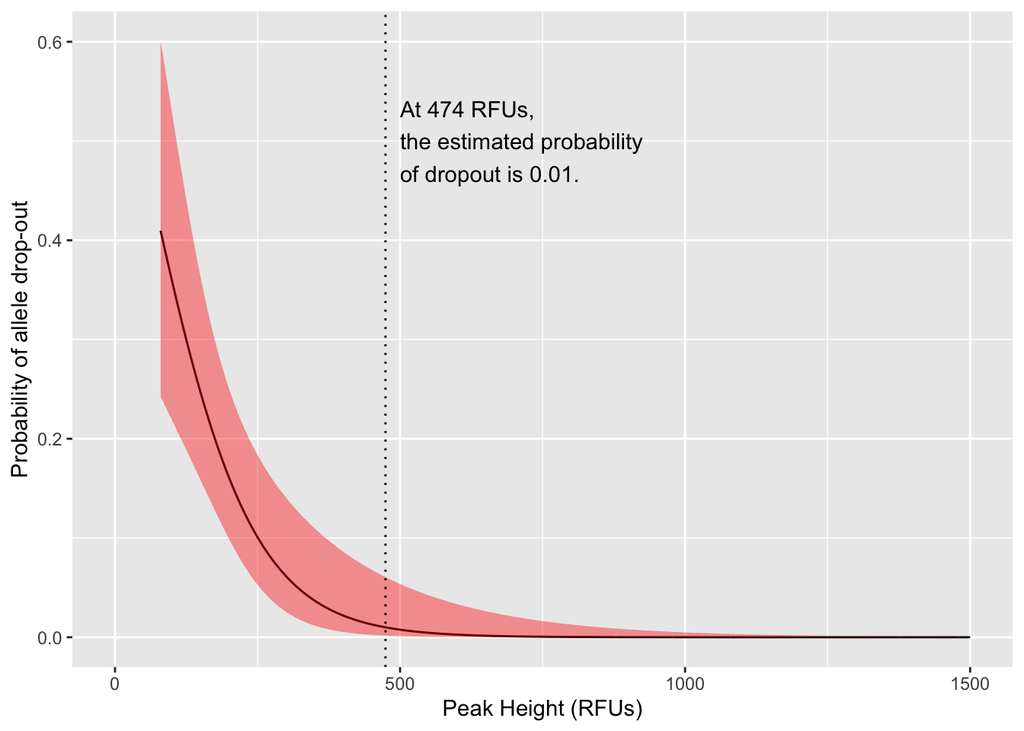

```r
xmin <- min(set4_do2$Exp, na.rm = T)
xmax <- max(set4_do2$Exp, na.rm = T)
predRange <- data.frame(Exp = seq(xmin, xmax))
ypred <- predict(do_mod, predRange, type = "link", se.fit = TRUE)
# 95% prediction interval
ylower <- plogis(ypred$fit - qnorm(1 - 0.05/2) * ypred$se)  # Lower confidence limit.
yupper <- plogis(ypred$fit + qnorm(1 - 0.05/2) * ypred$se)  # Upper confidence limit.
# Calculate conservative prediction curve.
yconservative <- plogis(ypred$fit + qnorm(1 - 0.05) * ypred$se)
# Calculate y values for plot.
yplot <- plogis(ypred$fit)
# combine them into a data frame for plotting
predictionDf <- data.frame(Exp = predRange$Exp, Prob = yplot, yupper = yupper,
    ylower = ylower)
# plot
th_dat <- data.frame(x = 500, y = 0.5, label = paste0("At ", round(set4_ths[1],
    0), " RFUs,\nthe estimated probability\nof dropout is 0.01."))
ggplot(data = predictionDf, aes(x = Exp, y = Prob)) + geom_line() + geom_ribbon(fill = "red",
    alpha = 0.4, aes(ymin = ylower, ymax = yupper)) + geom_vline(xintercept = set4_ths[1],
    linetype = "dotted") + geom_text(data = th_dat, inherit.aes = FALSE, aes(x = x,
    y = y, label = label), hjust = 0) + xlim(c(0, 1500)) + labs(x = "Peak Height (RFUs)",
    y = "Probability of allele drop-out")
```

We can also look at a heat map of dropout for each marker by sample:

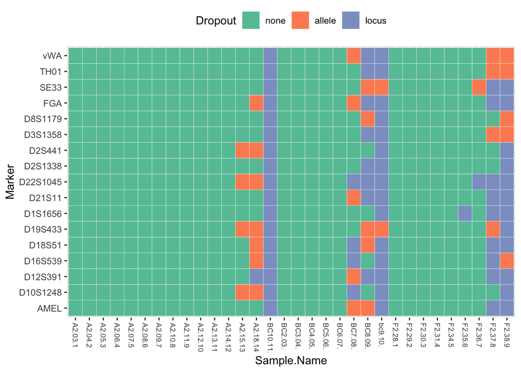

```r
set4_do %>% tidyr::separate(Sample.Name, into = c("num", "name", "num2")) %>%
    mutate(Sample.Name = paste(name, num, ifelse(is.na(num2), "", num2), sep = ".")) %>%
    ggplot(aes(x = Sample.Name, y = Marker, fill = as.factor(Dropout))) + geom_tile(color = "white") +
    scale_fill_brewer(name = "Dropout", palette = "Set2", labels = c("none",
        "allele", "locus")) + theme(axis.text.x = element_text(size = rel(0.8),
    angle = 270, hjust = 0, vjust = 0.5), legend.position = "top")
```